# HMM in Marine Sciences: Fitting a hidden Markov model to Accelerometer data

Marco Gallegos Herrada and Vinky Wang

# 1 Tutorial objectives

The aim of this tutorial is to delve into the process of fitting hidden Markov models (HMMs) to accelerometer data, integrating covariates into transition probabilities, and employing a classic model selection criterion to choose the most suitable model from a set of candidates. For all of this procedures, we will be using the R package `MomentuHMM`, introduced in first part of this workshop series.

# 2 Accelerometer data

Accelerometer devices measure up to three axes, which can be described relative to the body of the animal: longitudinal (surge), lateral (sway) and dorsoventral (heave). These devices are becoming more prevalent in the fields of animal biologging data as they provide a means of measuring activity in a meaningful and quantitative way. From tri-axial acceleration data, we can also derive several measures that summarize effort or exertion and relate acceleration to activity levels such as overall dynamic body acceleration (ODBA) and vectorial dynamic body acceleration (VeDBA).

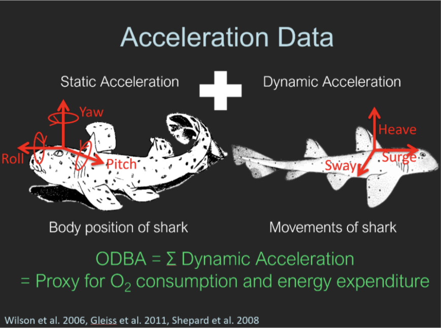

ODBA and VeDBA can be used to reduce the dimensionality of three-dimension acceleration data while retaining important information. Further, because acceleration data is often at high temporal resolutions over time, it also naturally exhibits a large degree of autocorrelation, making it impossible to assume independence between sequential observations. HMMs can account for the autocorrelation present in the data while assuming that the data were generated according to a finite set of (unobserved) behaviors making them a good candidate model for this type of data structure.

## 2.1 Blacktip Reef Shark data

In this tutorial, we will be analyzing four days’ worth of acceleration data from a free-ranging blacktip reef shark in the Palmyra Atoll located in the central Pacific Ocean. The acceleration data was collected from a 117-cm female shark (*Carcharhinus melanopterus*) species using a multisensor package. This package was attached to the shark’s dorsal fin and recorded three-dimensional acceleration data at a rate of 20 Hz. It also recorded depth and water temperature at a rate of 1 Hz. After four days, the package, which was equipped with a VHF transmitter, detached from the shark and could be retrieved from the water surface (Papastamatiou et al. 2015). To assess the shark’s active behavior, the authors calculated the average ODBA over 1-second intervals, resulting in a dataset comprising 320,214 observations. Consequently, the variables in the dataset consist of time of day, water temperature (in Celsius), depth (in meters), and ODBA.

```r
# R packages that will be used for this tutorial
library(readr)
library(momentuHMM)
library(ggplot2)
library(dplyr)
library(lubridate)


# Load data
BlacktipB <- read_delim("BlacktipB.txt",
                        delim = "\t", escape_double = FALSE,
                        trim_ws = TRUE)
```

```r
head(BlacktipB)
```

```
## # A tibble: 6 x 4
##   Time             Temp Depth   ODBA
##   <chr>           <dbl> <dbl>  <dbl>
## 1 7/10/2013 14:46  30.1   0.3 0.0672
## 2 7/10/2013 14:46  30.1   0.3 0.0298
## 3 7/10/2013 14:46  30.1   0.3 0.0422
## 4 7/10/2013 14:46  30.1   0.3 0.0748
## 5 7/10/2013 14:46  30.1   0.3 0.0442
## 6 7/10/2013 14:47  30.1   0.3 0.0995
```

## 2.2 Data processing

Looking at the ODBA values throughout the observed period, we find ODBA is unusually high at some times – for this shark we assumed that values between 0 and 2 were consistent with what we expected. The dashed blue line in the plot below corresponds to a ODBA value of 2, so those values that are above this line correspond to these high ODBA values throught the observed time period:

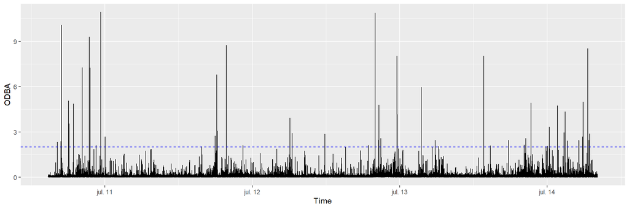

```r
BlacktipB_aux = BlacktipB %>%
  mutate(Time = as.POSIXct(Time,format = "%m/%d/%Y %H:%M"))

BlacktipB_aux %>%
  ggplot(aes(Time,ODBA)) +
  geom_line() + geom_hline(yintercept = 2,linetype="dashed",color="blue")
```

Because accommodating extreme values can pose a problem for identification of an adequate state-dependent distribution in our HMM, we removed them from the data set. However, note that in general, deciding whether to remove extreme values or not will more likely depend on whether we find appropriate distributional forms that can accommodate them. Generally, we need to make sure that extreme values are in fact some artefact of the data collection process, not representative of a behavior of interest, or inconsistent with what we are trying to capture as well. Removing data is not good general practice but instead we can assess on a case-by-case basis. Aditionally, for the interest of time, **in this tutorial we will be working with the 1-minute average depth, temperature and ODBA values** – this decrease significantly the amount of time required for the model fitting stage. As well, we will process the Time variable in order to have a datetime format.

```r
# Transform into proper time format and take 1-min avg
BlacktipB_1min = BlacktipB %>% filter(ODBA <= 2) %>%
  mutate(Time = as.POSIXct(Time,format = "%m/%d/%Y %H:%M")) %>%
  group_by(Time = cut(Time, breaks = "1 min")) %>%
  summarise(ODBA_avg = mean(ODBA),
            temp_avg = mean(Temp),
            depth_avg = mean(Depth)) %>%
  ungroup() %>%
  mutate(Time = as.POSIXct(Time,format = "%Y-%m-%d %H:%M:%S")) %>%
  as.data.frame()

head(BlacktipB_1min)
```

```
##                  Time   ODBA_avg temp_avg depth_avg
## 1 2013-07-10 14:46:00 0.05165654 30.10000 0.3000000
## 2 2013-07-10 14:47:00 0.05911752 30.10000 0.2983333
## 3 2013-07-10 14:48:00 0.04261436 30.20339 0.3271186
## 4 2013-07-10 14:49:00 0.04132418 30.81000 0.3550000
## 5 2013-07-10 14:50:00 0.04193025 31.86000 0.4050000
## 6 2013-07-10 14:51:00 0.03906949 31.31833 0.4283333
```

**After transforming the data, we can see the 1-minute average ODBA time series here across the four days. The horizontal red lines give us a clue of what could be the mean of two possible behaviours. These could be associated to “low-activity” behaviour (for the smallest values) and “high-activity” behaviour, associated to values that are relatively higher. Therefore, we can start proposing the model fitting with two behavioural states. Also note that there are no zero occurrences, since the purple horizontal line correspond the the y-intercept such that $y=0$.**

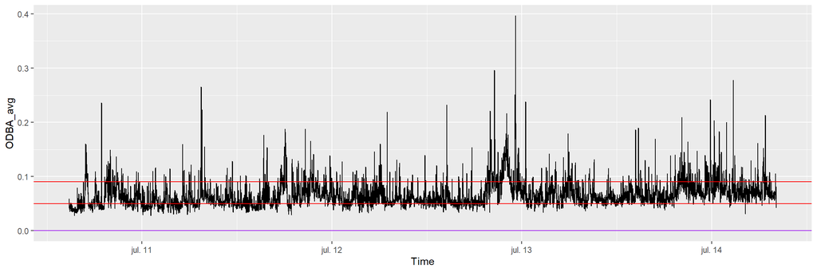

```r
BlacktipB_1min %>%
  ggplot(aes(Time,ODBA_avg)) +
  geom_line()  + geom_hline(yintercept = .05, color = "red") +
    geom_hline(yintercept = .09, color = "red") +
  geom_hline(yintercept = 0, color = "purple")
```

Now, according to the histogram of the observations associated to the ODBA values, the distribution suggest that a gamma distribution could be appropiate to model the data stream. This is reforced by the fact that we don’t have zero occurrences in this data stream, as can be visualized in the ODBA time series plot.

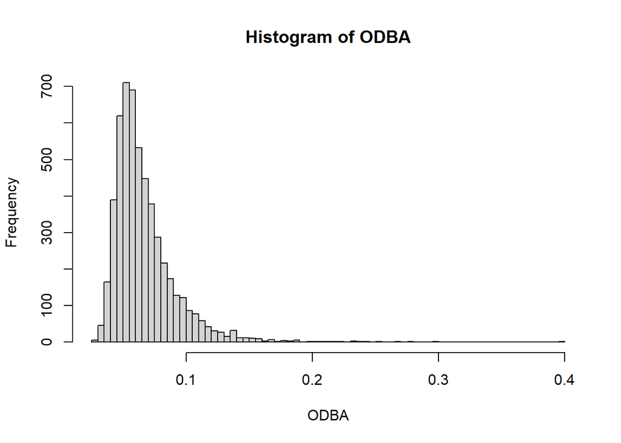

```r
hist(BlacktipB_1min$ODBA_avg,
     breaks = 80,
     main="Histogram of ODBA",
     xlab = "ODBA")
```

After selecting a data resolution and selecting a number of behaviour states, we are ready to start proposing candidate models for this data!

# 3 Model fitting

**The best way to start when fitting a hidden Markov model is to moving from simple models to more complex ones. Let’s recall that when fitting a hidden Markov model, we need to give as input two things.**

- Number of behavioral (hidden) states
- State-dependent distributions

From the latter, it’s important to mention that there’s a strong assumption being held. That is, the contemporaneous conditional independence assumption. If $\{ X_t \}$ is the observed process, and $\{ S_t \}$ is the behavioural process, for every time $t$, each data stream are independent conditional on the hidden states. This can be expressed as the following formula

$$f(\boldsymbol{x_{t}} \mid S_{t} = s_{t}) = \prod_{p=1}^P f(x_{tp} \mid S_{t} = s_{t}).$$

where $\boldsymbol{x_t} = (x_{t1},x_{t2},\ldots, x_{tP})$. For the current modeling procedure, we’re in a special case, since we only have one data stream. In this case, this assumption doesn’t need to be held, but for other cases, in which two or more data streams are accounted for the observation process, which is usually the case, for example, step length and step angle, this is an important assumption that allows the modelling of the each data stream.

Finally, for this model fitting stage, no additonal data will be incorporated in the state-switching dynamics – which translates in not including covariances in the transition probabilities allocated in the transition probability matrix. As part of the data preparation, we need to process the data using the `prepData` function, which will assign the class `momentuHMMData` to our dataframe. This will allow us to use the functions provided by `momentuHMM`. Since we’re not using coordinate variables to transform them into step lengths, we need to seet the parameter coordNames to `NULL`.

```r
BlacktipBData = prepData(BlacktipB_1min,coordNames = NULL)
```

```r
stateNames = c("low-activity","high-activity") # define names for each state
mu0 = c(.05,.09) # initial values for the mean of each behavioural state
sigma0 = c(.02,.02) # initial values for the standard deviation of each behavioural state
fit1 = fitHMM(BlacktipBData,
              nbStates=2,
              stateNames = stateNames,
              dist=list(ODBA_avg="gamma"),
              Par0 = list(ODBA_avg=c(mu0,sigma0)))

fit1
```

```
## Value of the maximum log-likelihood: 14462.08
##
##
## ODBA_avg parameters:
## --------------------
##      low-activity high-activity
## mean   0.05387998    0.08484691
## sd     0.01008312    0.02486110
##
## Regression coeffs for the transition probabilities:
## ---------------------------------------------------
##                1 -> 2    2 -> 1
## (Intercept) -2.955513 -2.603855
##
## Transition probability matrix:
## ------------------------------
##               low-activity high-activity
## low-activity    0.95052338    0.04947662
## high-activity   0.06889075    0.93110925
##
## Initial distribution:
## ---------------------
##  low-activity high-activity
##  0.9998487757  0.0001512243
```

```r
c=100
BlacktipB_1min$cODBA_avg = c*BlacktipB_1min$ODBA_avg
BlacktipBData = prepData(BlacktipB_1min,coordNames = NULL)
cmu0 = c*mu0 # initial values for the mean of each behavioural state
csigma0 = c*sigma0 # initial values for the standard deviation of each behavioural state
cfit1 = fitHMM(BlacktipBData,
              nbStates=2,
              stateNames = stateNames,
              dist=list(cODBA_avg="gamma"),
              Par0 = list(cODBA_avg=c(cmu0,csigma0)))

cfit1
```

```
## Value of the maximum log-likelihood: -10244.66
##
##
## cODBA_avg parameters:
## ---------------------
##      low-activity high-activity
## mean     5.388008      8.484708
## sd       1.008319      2.486118
##
## Regression coeffs for the transition probabilities:
## ---------------------------------------------------
##                1 -> 2    2 -> 1
## (Intercept) -2.955524 -2.603854
##
## Transition probability matrix:
## ------------------------------
##               low-activity high-activity
## low-activity    0.95052391    0.04947609
## high-activity   0.06889081    0.93110919
##
## Initial distribution:
## ---------------------
##  low-activity high-activity
##   0.999858579   0.000141421
```

**We can also plot the results to obtain a visual representation of the fitted model. Using the function `plot`, we can see the state-dependent distributions using the estimated parameters. The plot below makes sense in terms of the low-activity and high-activity behaviours, with the distribution of the low-activity high-density area being more concentrated to values closer to zero and high-activity behaviour having their probability mass shifted to higher (scaled) 1-min average ODBA values.**

```
## Decoding state sequence... DONE
```

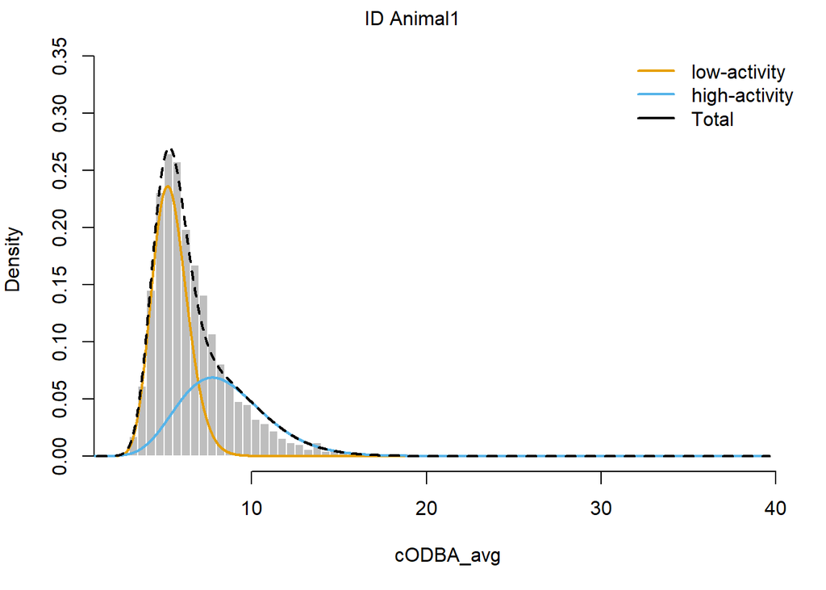

```r
plot(cfit1,breaks = 80)
```

Let’s examine the pseudo-residuals. By using the `plotPR` function, we can visualize these pseudo-residuals. This function displays the pseudo-residual time series, qq-plots, and autocorrelation functions (ACF). It’s important to note that pseudo-residuals are a specific type of model residuals that consider the interdependence of observations. Pseudo-residuals are computed for each data stream, and in our case, we are only considering ODBA values, resulting in a single plot of pseudo-residuals. It’s worth remembering that when the fitted model is appropriate, the pseudo-residuals should adhere to a standard normal distribution. However, based on the following plots, it appears that the model doesn’t fit well for high (scaled) ODBA values. Furthermore, the ACF plot indicates a significant autocorrelation between observations in the (scaled) ODBA time series, suggesting that the model fails to capture this autocorrelation. Notably, there is a substantial level of autocorrelation and some deviation from normality.

```
## Computing pseudo-residuals...
```

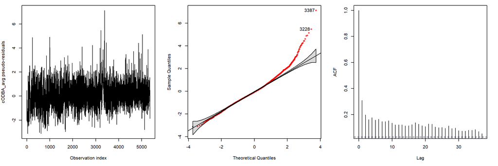

```r
plotPR(cfit1)
```

```r
# identify most likely state using the Viterbi algorithm
BlacktipB_1min$state <- factor(viterbi(fit1))

# proportion of the behaviour states during the observed period
table(BlacktipB_1min$state)/length(BlacktipB_1min$state)
```

```
##
##         1         2
## 0.5882572 0.4117428
```

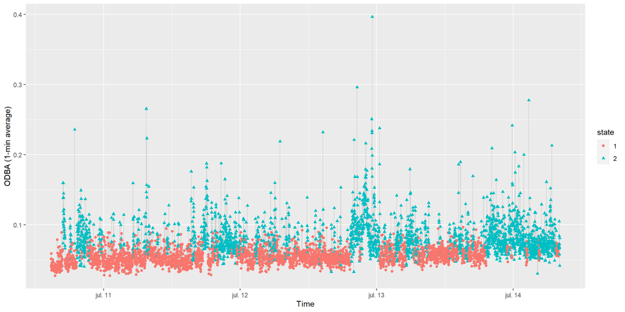

```r
BlacktipB_1min %>% mutate(day = day(Time)) %>%
  ggplot(aes(Time,ODBA_avg)) +
  #facet_wrap(~day,scales = "free_x") +
  geom_line(alpha=.1) +
  geom_point(aes(shape=state,color=state)) + ylab("ODBA (1-min average)")
```

```r
# identify most likely state using the Viterbi algorithm (scaled ODBA)
BlacktipB_1min$cstate <- factor(viterbi(cfit1))

# proportion of the behaviour states during the observed period
table(BlacktipB_1min$cstate)/length(BlacktipB_1min$cstate)
```

```
##
##         1         2
## 0.5882572 0.4117428
```

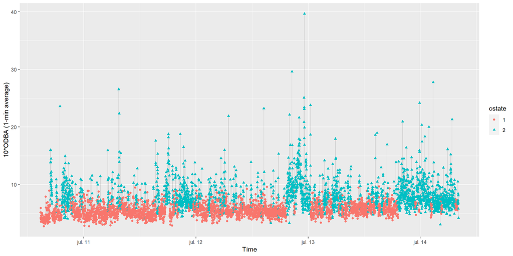

```r
BlacktipB_1min %>% mutate(day = day(Time)) %>%
  ggplot(aes(Time,cODBA_avg)) +
  #facet_wrap(~day,scales = "free_x") +
  geom_line(alpha=.1) +
  geom_point(aes(shape=cstate,color=cstate)) + ylab("10*ODBA (1-min average)")
```

An essential stage in model fitting is to verify if the parameter estimates correspond to the actual Maximum Likelihood Estimation (MLE). HMMs can be susceptible to initial values, so we need a procedure to assess the reliability of the parameter estimates. The argument `retryFits` in `fitHMM` specifies the number of times initial values are perturbed before model fitting takes place. Here, we attempt to refit the model 10 times to assess whether we have identified the global maximum. This can take time to run.

```r
set.seed(147)
fit1_s2 <- fitHMM(BlacktipBData,
                  nbState = 2,
                  stateNames = stateNames,
                  dist=list(cODBA_avg="gamma"),
                  Par0 = list(cODBA_avg=c(cmu0,csigma0)),
                  retryFits=10)
```

```
## Attempting to improve fit using random perturbation. Press 'esc' to force exit from 'fitHMM'
##
    Attempt 1 of 10 -- current log-likelihood value: -10244.66
    Attempt 2 of 10 -- current log-likelihood value: -10244.66
    Attempt 3 of 10 -- current log-likelihood value: -10244.66
    Attempt 4 of 10 -- current log-likelihood value: -10244.66
    Attempt 5 of 10 -- current log-likelihood value: -10244.66
    Attempt 6 of 10 -- current log-likelihood value: -10244.66
    Attempt 7 of 10 -- current log-likelihood value: -10244.66
    Attempt 8 of 10 -- current log-likelihood value: -10244.66
    Attempt 9 of 10 -- current log-likelihood value: -10244.66
    Attempt 10 of 10 -- current log-likelihood value: -10244.66
```

```r
fit1_s2
```

```
## Value of the maximum log-likelihood: -10244.66
##
##
## cODBA_avg parameters:
## ---------------------
##      low-activity high-activity
## mean     5.388008      8.484711
## sd       1.008319      2.486118
##
## Regression coeffs for the transition probabilities:
## ---------------------------------------------------
##                1 -> 2   2 -> 1
## (Intercept) -2.955526 -2.60385
##
## Transition probability matrix:
## ------------------------------
##               low-activity high-activity
## low-activity    0.95052401    0.04947599
## high-activity   0.06889107    0.93110893
##
## Initial distribution:
## ---------------------
##  low-activity high-activity
##  9.999996e-01  3.983681e-07
```

Seems nothing changed at all!

Let’s go further by introducing a high perturbation to the initial values. Specifically, instead of 5 and 9, we will use 0.1 and 100 for the mean parameters. Additionally, for the initial values related to the standard deviation, we will set them at 100 for each state-dependent distribution. It’s important to emphasize that regardless of the initial values, the coefficients should be the same. Indeed, we can observe that the estimated coefficients and log-likelihood values are still similar.

```r
mu1 = c*c(.001,1)
sigma1 = c*c(1,1)

fit1_s2_long <- fitHMM(BlacktipBData,
                  nbState = 2,
                  stateNames = stateNames,
                  dist=list(cODBA_avg="gamma"),
                  Par0 = list(cODBA_avg=c(mu1,sigma1)))

fit1_s2_long
```

```
## Value of the maximum log-likelihood: -10244.66
##
##
## cODBA_avg parameters:
## ---------------------
##      low-activity high-activity
## mean     8.484709      5.388007
## sd       2.486118      1.008318
##
## Regression coeffs for the transition probabilities:
## ---------------------------------------------------
##                1 -> 2   2 -> 1
## (Intercept) -2.603852 -2.95552
##
## Transition probability matrix:
## ------------------------------
##               low-activity high-activity
## low-activity    0.93110910     0.0688909
## high-activity   0.04947625     0.9505238
##
## Initial distribution:
## ---------------------
##  low-activity high-activity
##  8.616207e-07  9.999991e-01
```

```r
mu2 = c*c(.04,.06) # This gives 4 and 6 as initial values for estimating the mean parameters
sigma2 = c*c(.02,.02) # This gives 2 and 2 as initial values for estimating the mean parameters

fit1_s3 <- fitHMM(BlacktipBData,
                  nbState = 2,
                  dist=list(cODBA_avg="gamma"),
                  Par0 = list(cODBA_avg=c(mu2,sigma2)))

fit1_s3
```

```
## Value of the maximum log-likelihood: -10244.66
##
##
## cODBA_avg parameters:
## ---------------------
##       state 1  state 2
## mean 5.388009 8.484710
## sd   1.008320 2.486119
##
## Regression coeffs for the transition probabilities:
## ---------------------------------------------------
##                1 -> 2    2 -> 1
## (Intercept) -2.955528 -2.603861
##
## Transition probability matrix:
## ------------------------------
##            state 1    state 2
## state 1 0.95052411 0.04947589
## state 2 0.06889035 0.93110965
##
## Initial distribution:
## ---------------------
##      state 1      state 2
## 9.999895e-01 1.051319e-05
```

**Using the function `plotPR`, we can look that pseudo-residuals remained the same besides having this state parameter switching.**

```
## Computing pseudo-residuals...
```

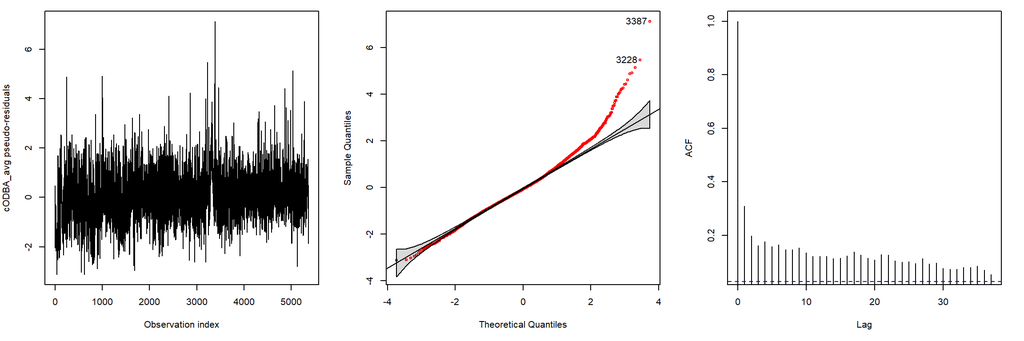

```r
plotPR(fit1_s2_long)
```

**When computing the most likely sequence of states (viterby sequence), we notice that the values got inverted, since the model fitting now for state 1 correspond to “high-activity” behaviour and state 2 corresponds to “low-activity” behaviour!**

```r
# identify most likely state using the Viterbi algorithm
BlacktipB_1min$state_wildPar0 <- factor(viterbi(fit1_s2_long))

# proportion of the behaviour states during the observed period
table(BlacktipB_1min$state_wildPar0)/length(BlacktipB_1min$state_wildPar0)
```

```
##
##         1         2
## 0.4117428 0.5882572
```

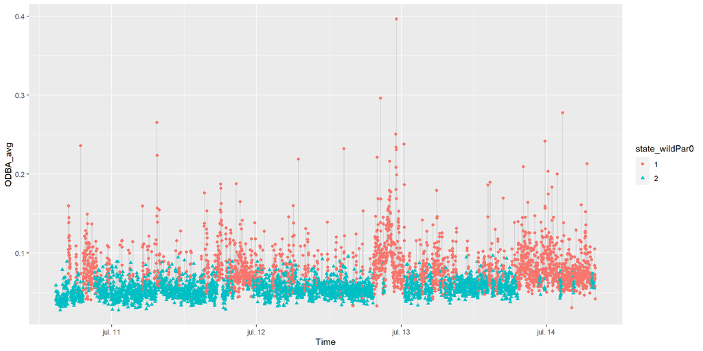

```r
# BlacktipB_1min %>% mutate(day = day(Time)) %>%
#   ggplot(aes(Time,state_wildPar0)) + facet_wrap(~day) + geom_point()

BlacktipB_1min %>% mutate(day = day(Time)) %>%
  ggplot(aes(Time,ODBA_avg)) +
  #facet_wrap(~day,scales = "free_x") +
  geom_line(alpha=.1) +
  geom_point(aes(shape=state_wildPar0,color=state_wildPar0))
```

**We mentioned when fitting this model that there were no incorporation of covariates into the transition probabilities. As well, we noticed that ACF plot indicated a high autocorrelation between observations that the model was not able to capture. Maybe adding accounting for other data streams can help in reducing this autocorrelation. For this, we can explore the incorporation of covarites in the state-switching dynamics, and see what happens.**

# 4 Incorporating covariates

**As in Leos-Barajas et al. 2017, we can incorporate other information that may help explain the values of ODBA. In this case, we consider the minute of the day of every observation. Time of day is represented by two trigonometric functions with period 24 h, $cos(2\pi (t/60)/24)$ and $sin(2\pi (t/60)/24$. Using the function cosinor, we can convert our data stream to something that is useful for us. As well, we need to provide the formula corresponding to the regression that will be stored in the transition probability values. We will fit two models accounting for these, in which we will have the original and the scaled 1-minute average ODBA data stream. Looking at the output, we have that both have very similar, if not the same, parameter estimates associated to the transition probabilities and the initial state distribution, whereas the state-dependent distribution parameters differ by up to the scale used.**

```r
# formula corresponding to the regression coefficients for the transition probabilities
# re-prep data
# BlacktipB_1min <- BlacktipB_1min %>%
#   mutate(lag = 0:(n() - 1),
#          sin_part = sin(2*pi*lag*(1/60)/24),
#          cos_part = cos(2*pi*lag*(1/60)/24)
#          )

BlacktipB_1min = BlacktipB_1min %>%
  mutate(min_day = time_length(hm(format(Time,format = "%H:%M")),unit = "minutes"))


BlacktipBData = prepData(BlacktipB_1min,coordNames = NULL, covNames = c("min_day"))

# re-fit model 1
fit1 = fitHMM(BlacktipBData,nbStates=2,dist=list(ODBA_avg="gamma"),
              Par0 = list(ODBA_avg=c(.05,.09,.02,.02)))


formula = ~ cosinor(min_day, period = 1440)

Par0_fit2 <- getPar0(model=fit1,
                     formula=formula)

fit2 = fitHMM(BlacktipBData,
              nbStates=2,
              dist=list(ODBA_avg="gamma"),
              Par0 = Par0_fit2$Par,formula=formula)

fit2
```

```
## Value of the maximum log-likelihood: 14493.14
##
##
## ODBA_avg parameters:
## --------------------
##         state 1    state 2
## mean 0.05386968 0.08500875
## sd   0.01004035 0.02485230
##
## Regression coeffs for the transition probabilities:
## ---------------------------------------------------
##                                         1 -> 2     2 -> 1
## (Intercept)                        -2.88275805 -2.3524761
## cosinorCos(min_day, period = 1440)  0.03901202 -1.1509139
## cosinorSin(min_day, period = 1440)  0.24743328  0.2520174
##
## Transition probability matrix (based on mean covariate values):
## ---------------------------------------------------------------
##           state 1    state 2
## state 1 0.9490072 0.05099275
## state 2 0.2308356 0.76916438
##
## Initial distribution:
## ---------------------
##      state 1      state 2
## 0.9998523609 0.0001476391
```

```r
# re-fit model 1
cfit1 = fitHMM(BlacktipBData,nbStates=2,dist=list(cODBA_avg="gamma"),
              Par0 = list(cODBA_avg=c*c(.05,.09,.02,.02)))

formula = ~ cosinor(min_day, period = 1440)

Par0_cfit2 <- getPar0(model=cfit1,
                     formula=formula)

cfit2 = fitHMM(BlacktipBData,nbStates=2,
               dist=list(cODBA_avg="gamma"),
               Par0 = Par0_cfit2$Par,formula=formula)

cfit2
```

```
## Value of the maximum log-likelihood: -10213.6
##
##
## cODBA_avg parameters:
## ---------------------
##       state 1  state 2
## mean 5.386977 8.500890
## sd   1.004041 2.485238
##
## Regression coeffs for the transition probabilities:
## ---------------------------------------------------
##                                         1 -> 2     2 -> 1
## (Intercept)                        -2.88276783 -2.3524704
## cosinorCos(min_day, period = 1440)  0.03901346 -1.1509154
## cosinorSin(min_day, period = 1440)  0.24743346  0.2520221
##
## Transition probability matrix (based on mean covariate values):
## ---------------------------------------------------------------
##           state 1    state 2
## state 1 0.9490078 0.05099221
## state 2 0.2308369 0.76916312
##
## Initial distribution:
## ---------------------
##      state 1      state 2
## 0.9998524371 0.0001475629
```

```
## Decoding state sequence... DONE
```

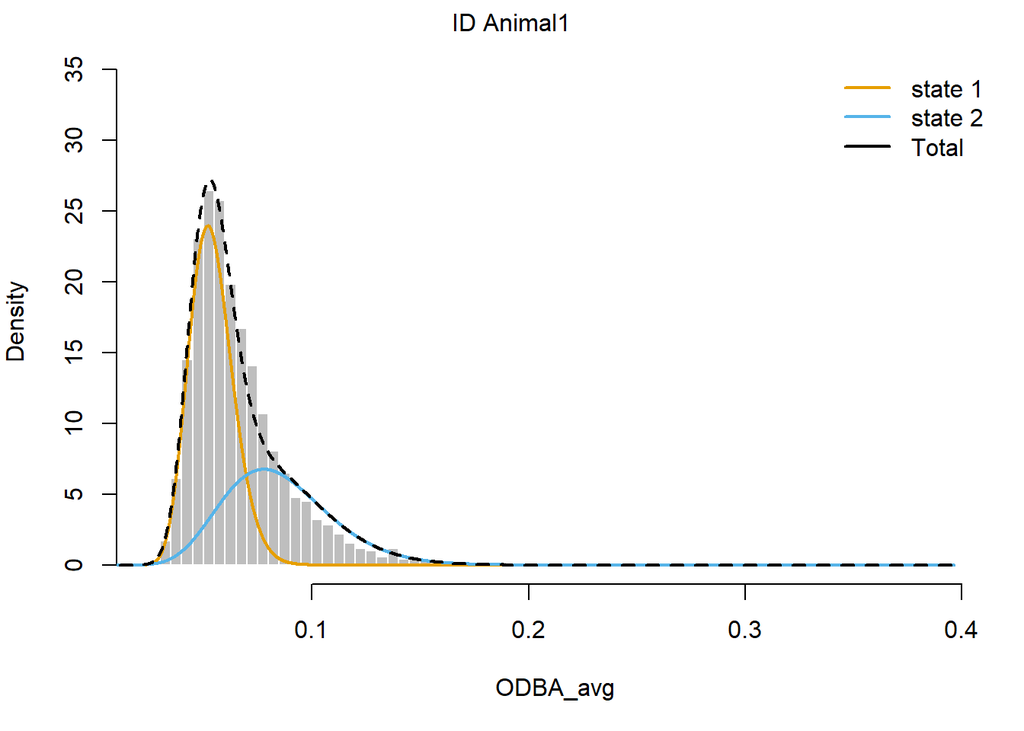

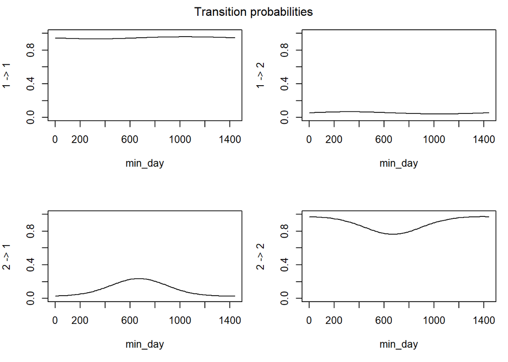

```r
plot(fit2,breaks=80)
```

```
## Decoding state sequence... DONE
```

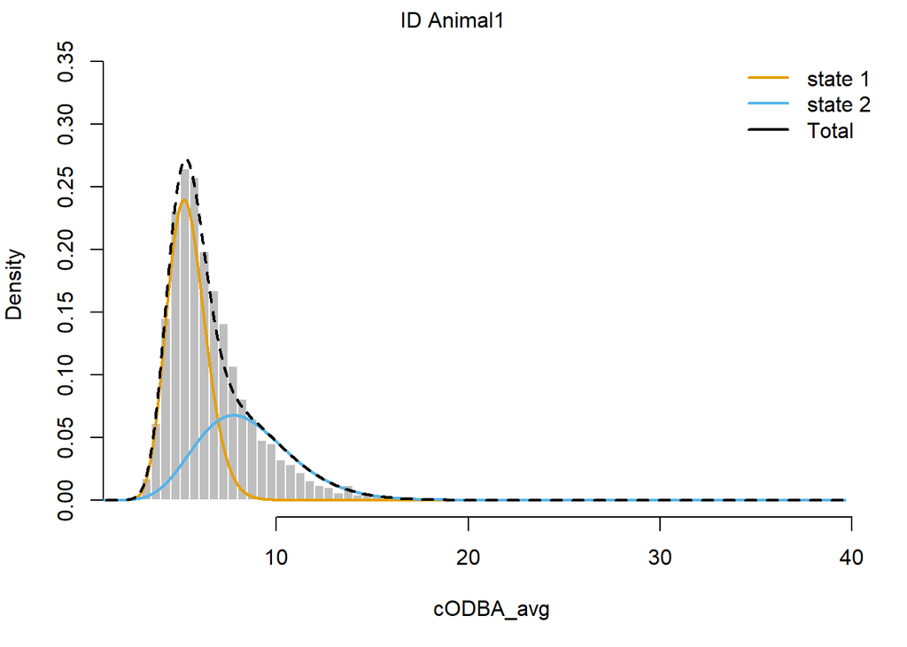

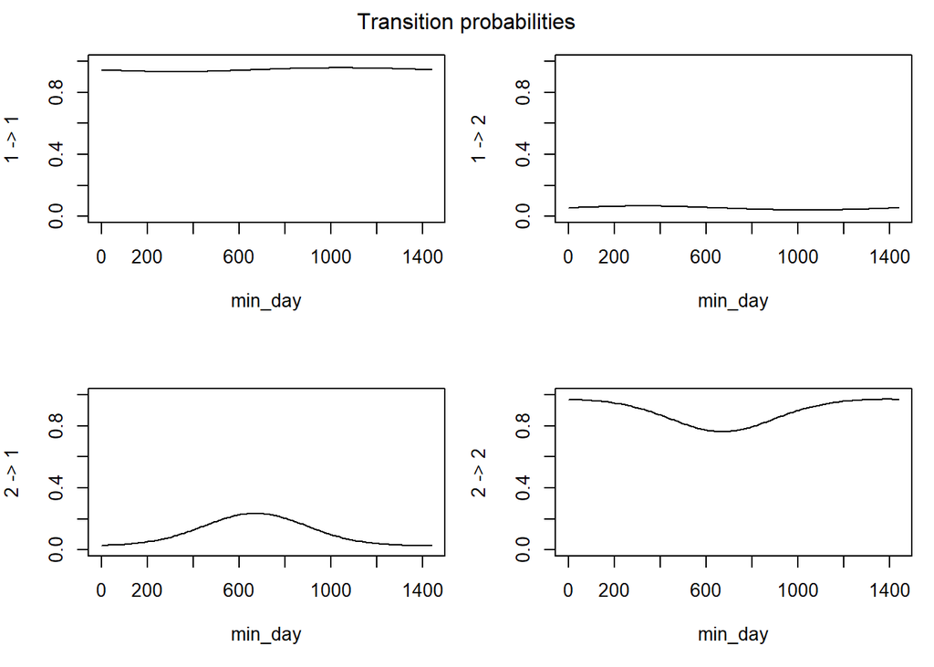

```r
plot(cfit2,breaks=80)
```

```
## Computing pseudo-residuals...
```

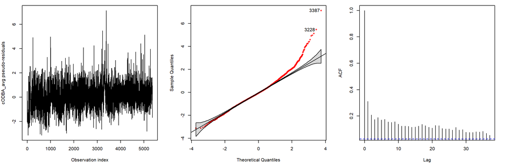

```r
plotPR(cfit2)
```

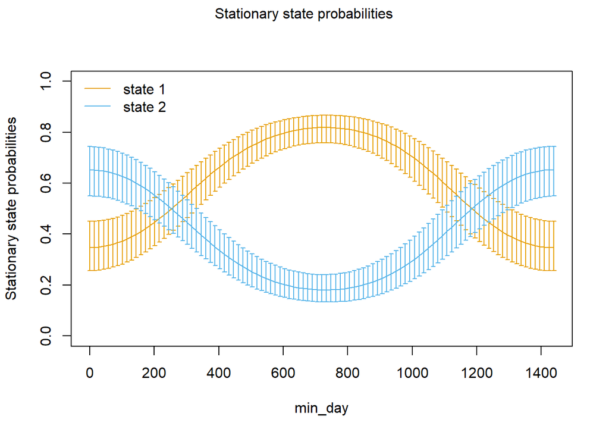

```r
plotStationary(cfit2, plotCI = TRUE)
```

# 5 Model section: Akaike Information Criteria (AIC)

```r
AIC(fit1)
```

```
## [1] -28910.16
```

```r
AIC(fit2)
```

```
## [1] -28964.28
```

```r
AIC(cfit1)
```

```
## [1] 20503.32
```

```r
AIC(cfit2)
```

```
## [1] 20449.2
```

# 6 Exercises

1. Reproduce the analysis from the blacktip reef shark data, but now consider three beahviour states instead of only two. For this, do an EDA to try to set initial values for the state-dependent distribution parameters. Look at the pseudo-residual values and the ACF plot. Does the autocorrelation reduces when considering another behavioural state.
   - Is there a noticeable difference in the ACF compared to the initial 2-state HMM?
2. For the 2-state HMM, try to incorporate another variables as covariates (consider the 1-minute average temperature and depth variables). Fit this new model helping yourself from the code above.
   - What are the AIC and the log-likelihood values? How are these different from the values related to the second model fitted. Based on the Akaike Information Criteria, which model seems to be the “best”?